# User Guide: 1 Debugging ggplots

‘gginnards’ 0.0.3

Pedro J. Aphalo

2019-11-26

## Preliminaries

```r
library(gginnards)
library(tibble)
```

We generate some artificial data.

```r
set.seed(4321)
# generate artificial data
x <- 1:100
y <- (x + x^2 + x^3) + rnorm(length(x), mean = 0, sd = mean(x^3) / 4)
my.data <- data.frame(x,
                      y,
                      group = c("A", "B"),
                      y2 = y * c(0.5, 2),
                      block = c("a", "a", "b", "b"))
```

We change the default theme to an uncluttered one.

```r
old_theme <- theme_set(theme_bw())
```

# ggplot construction

Package ‘ggplot2’ defines its own class system, and function `ggplot()` can be considered as a constructor.

```r
class(ggplot())
```

```
## [1] "gg"     "ggplot"
```

These objects contain all the information needed to render a plot into graphical output, but not the rendered plot itself. They are list-like objects with heterogeneous named members.

The structure of objects of class `"ggplot"` can be explored with R’s method `str()` as is the case for any structured R object. Package ‘gginnards’ defines a a specialization of `str()` for class `"ggplot"`. Our `str()` allows us to see the different *slots* of these special type of lists. The difference with the default `str()` method is in the values of default arguments, and in the ability to control which components or members are displayed.

We will use the `str()` to follow the step by step construction of a `"ggplot"` object.

If we pass no arguments to the `ggplot()` constructor an empty plot will be rendered if we print it.

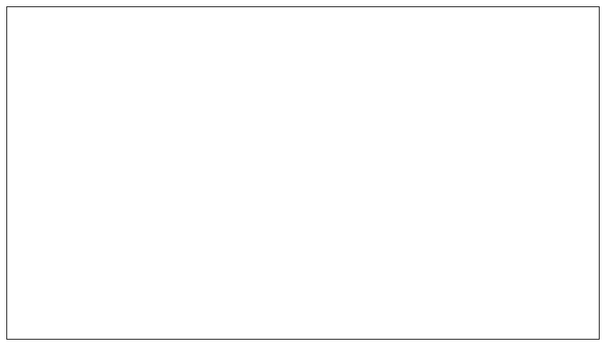

```r
p0 <- ggplot()
p0
```

Object `p` contains members, but `"data"`, `"layers"`, `"mapping"`, `"theme"` and `"labels"` are empty lists.

```r
str(p0)
```

```
## Object size: 3.4 kB
## List of 9
##  $ data       : list()
##  $ layers     : list()
##  $ scales     :Classes 'ScalesList', 'ggproto', 'gg' <ggproto object: Class ScalesList, gg>
##     add: function
##     clone: function
##     find: function
##     get_scales: function
##     has_scale: function
##     input: function
##     n: function
##     non_position_scales: function
##     scales: NULL
##     super:  <ggproto object: Class ScalesList, gg>
##  $ mapping    : Named list()
##  $ theme      : list()
##  $ coordinates:Classes 'CoordCartesian', 'Coord', 'ggproto', 'gg' <ggproto object: Class CoordCartesian, Coord, gg>
##     aspect: function
##     backtransform_range: function
##     clip: on
##     default: TRUE
##     distance: function
##     expand: TRUE
##     is_free: function
##     is_linear: function
##     labels: function
##     limits: list
##     modify_scales: function
##     range: function
##     render_axis_h: function
##     render_axis_v: function
##     render_bg: function
##     render_fg: function
##     setup_data: function
##     setup_layout: function
##     setup_panel_params: function
##     setup_params: function
##     transform: function
##     super:  <ggproto object: Class CoordCartesian, Coord, gg>
##  $ facet      :Classes 'FacetNull', 'Facet', 'ggproto', 'gg' <ggproto object: Class FacetNull, Facet, gg>
##     compute_layout: function
##     draw_back: function
##     draw_front: function
##     draw_labels: function
##     draw_panels: function
##     finish_data: function
##     init_scales: function
##     map_data: function
##     params: list
##     setup_data: function
##     setup_params: function
##     shrink: TRUE
##     train_scales: function
##     vars: function
##     super:  <ggproto object: Class FacetNull, Facet, gg>
##  $ plot_env   :<environment: R_GlobalEnv>
##  $ labels     : Named list()
```

If we pass an argument to parameter `data` the data is copied into the list slot with name `data`. As we also map the data to aesthetics, this mapping is stored in slot `maaping`.

```r
p1 <- ggplot(data = my.data, aes(x, y, colour = group))
str(p1)
```

```
## Object size: 11 kB
## List of 9
##  $ data       :'data.frame': 100 obs. of  5 variables:
##  $ layers     : list()
##  $ scales     :Classes 'ScalesList', 'ggproto', 'gg' <ggproto object: Class ScalesList, gg>
##     add: function
##     clone: function
##     find: function
##     get_scales: function
##     has_scale: function
##     input: function
##     n: function
##     non_position_scales: function
##     scales: NULL
##     super:  <ggproto object: Class ScalesList, gg>
##  $ mapping    :List of 3
##  $ theme      : list()
##  $ coordinates:Classes 'CoordCartesian', 'Coord', 'ggproto', 'gg' <ggproto object: Class CoordCartesian, Coord, gg>
##     aspect: function
##     backtransform_range: function
##     clip: on
##     default: TRUE
##     distance: function
##     expand: TRUE
##     is_free: function
##     is_linear: function
##     labels: function
##     limits: list
##     modify_scales: function
##     range: function
##     render_axis_h: function
##     render_axis_v: function
##     render_bg: function
##     render_fg: function
##     setup_data: function
##     setup_layout: function
##     setup_panel_params: function
##     setup_params: function
##     transform: function
##     super:  <ggproto object: Class CoordCartesian, Coord, gg>
##  $ facet      :Classes 'FacetNull', 'Facet', 'ggproto', 'gg' <ggproto object: Class FacetNull, Facet, gg>
##     compute_layout: function
##     draw_back: function
##     draw_front: function
##     draw_labels: function
##     draw_panels: function
##     finish_data: function
##     init_scales: function
##     map_data: function
##     params: list
##     setup_data: function
##     setup_params: function
##     shrink: TRUE
##     train_scales: function
##     vars: function
##     super:  <ggproto object: Class FacetNull, Facet, gg>
##  $ plot_env   :<environment: R_GlobalEnv>
##  $ labels     :List of 3
```

```r
str(p1, max.level = 2, components = "data")
```

```
## Object size: 5.3 kB
## List of 1
##  $ data:'data.frame':    100 obs. of  5 variables:
##   ..$ x    : int [1:100] 1 2 3 4 5 ...
##   ..$ y    : num [1:100] -27205 -14243 ...
##   ..$ group: Factor w/ 2 levels "A","B": 1 2 1 2 1 ...
##   ..$ y2   : num [1:100] -13603 -28485 ...
##   ..$ block: Factor w/ 2 levels "a","b": 1 1 2 2 1 ...
```

A geometry adds a layer.

```r
p2 <- p1 + geom_point()
str(p2)
```

```
## Object size: 11.5 kB
## List of 9
##  $ data       :'data.frame': 100 obs. of  5 variables:
##  $ layers     :List of 1
##  $ scales     :Classes 'ScalesList', 'ggproto', 'gg' <ggproto object: Class ScalesList, gg>
##     add: function
##     clone: function
##     find: function
##     get_scales: function
##     has_scale: function
##     input: function
##     n: function
##     non_position_scales: function
##     scales: list
##     super:  <ggproto object: Class ScalesList, gg>
##  $ mapping    :List of 3
##  $ theme      : list()
##  $ coordinates:Classes 'CoordCartesian', 'Coord', 'ggproto', 'gg' <ggproto object: Class CoordCartesian, Coord, gg>
##     aspect: function
##     backtransform_range: function
##     clip: on
##     default: TRUE
##     distance: function
##     expand: TRUE
##     is_free: function
##     is_linear: function
##     labels: function
##     limits: list
##     modify_scales: function
##     range: function
##     render_axis_h: function
##     render_axis_v: function
##     render_bg: function
##     render_fg: function
##     setup_data: function
##     setup_layout: function
##     setup_panel_params: function
##     setup_params: function
##     transform: function
##     super:  <ggproto object: Class CoordCartesian, Coord, gg>
##  $ facet      :Classes 'FacetNull', 'Facet', 'ggproto', 'gg' <ggproto object: Class FacetNull, Facet, gg>
##     compute_layout: function
##     draw_back: function
##     draw_front: function
##     draw_labels: function
##     draw_panels: function
##     finish_data: function
##     init_scales: function
##     map_data: function
##     params: list
##     setup_data: function
##     setup_params: function
##     shrink: TRUE
##     train_scales: function
##     vars: function
##     super:  <ggproto object: Class FacetNull, Facet, gg>
##  $ plot_env   :<environment: R_GlobalEnv>
##  $ labels     :List of 3
```

A `summary()` method that produces a more compact output is available in recent versions of ‘ggplot2’. However, it does not reveal the internal structure of the objects.

```r
summary(p2)
```

```
## data: x, y, group, y2, block [100x5]
## mapping:  x = ~x, y = ~y, colour = ~group
## faceting: <ggproto object: Class FacetNull, Facet, gg>
##     compute_layout: function
##     draw_back: function
##     draw_front: function
##     draw_labels: function
##     draw_panels: function
##     finish_data: function
##     init_scales: function
##     map_data: function
##     params: list
##     setup_data: function
##     setup_params: function
##     shrink: TRUE
##     train_scales: function
##     vars: function
##     super:  <ggproto object: Class FacetNull, Facet, gg>
## -----------------------------------
## geom_point: na.rm = FALSE
## stat_identity: na.rm = FALSE
## position_identity
```

```r
str(p2, max.level = 2, components = "mapping")
```

```
## Object size: 3 kB
## List of 1
##  $ mapping:List of 3
##   ..$ x     : language ~x
##   ..$ y     : language ~y
##   ..$ colour: language ~group
```

```r
p3 <- p2 + theme_classic()
str(p3)
```

```
## Object size: 78 kB
## List of 9
##  $ data       :'data.frame': 100 obs. of  5 variables:
##  $ layers     :List of 1
##  $ scales     :Classes 'ScalesList', 'ggproto', 'gg' <ggproto object: Class ScalesList, gg>
##     add: function
##     clone: function
##     find: function
##     get_scales: function
##     has_scale: function
##     input: function
##     n: function
##     non_position_scales: function
##     scales: list
##     super:  <ggproto object: Class ScalesList, gg>
##  $ mapping    :List of 3
##  $ theme      :List of 66
##  $ coordinates:Classes 'CoordCartesian', 'Coord', 'ggproto', 'gg' <ggproto object: Class CoordCartesian, Coord, gg>
##     aspect: function
##     backtransform_range: function
##     clip: on
##     default: TRUE
##     distance: function
##     expand: TRUE
##     is_free: function
##     is_linear: function
##     labels: function
##     limits: list
##     modify_scales: function
##     range: function
##     render_axis_h: function
##     render_axis_v: function
##     render_bg: function
##     render_fg: function
##     setup_data: function
##     setup_layout: function
##     setup_panel_params: function
##     setup_params: function
##     transform: function
##     super:  <ggproto object: Class CoordCartesian, Coord, gg>
##  $ facet      :Classes 'FacetNull', 'Facet', 'ggproto', 'gg' <ggproto object: Class FacetNull, Facet, gg>
##     compute_layout: function
##     draw_back: function
##     draw_front: function
##     draw_labels: function
##     draw_panels: function
##     finish_data: function
##     init_scales: function
##     map_data: function
##     params: list
##     setup_data: function
##     setup_params: function
##     shrink: TRUE
##     train_scales: function
##     vars: function
##     super:  <ggproto object: Class FacetNull, Facet, gg>
##  $ plot_env   :<environment: R_GlobalEnv>
##  $ labels     :List of 3
```

Themes are stored as nested lists. To keep the output short we use `max.level = 2` although using `max.level = 3` would be needed to see all nested members.

```r
str(p3, max.level = 2, components = "theme")
```

```
## Object size: 66.8 kB
## List of 1
##  $ theme:List of 66
##   ..$ line                      :List of 6
##   ..$ rect                      :List of 5
##   ..$ text                      :List of 11
##   ..$ axis.title.x              :List of 11
##   ..$ axis.title.x.top          :List of 11
##   ..$ axis.title.y              :List of 11
##   ..$ axis.title.y.right        :List of 11
##   ..$ axis.text                 :List of 11
##   ..$ axis.text.x               :List of 11
##   ..$ axis.text.x.top           :List of 11
##   ..$ axis.text.y               :List of 11
##   ..$ axis.text.y.right         :List of 11
##   ..$ axis.ticks                :List of 6
##   ..$ axis.ticks.length         : 'unit' num 2.75pt
##   ..$ axis.ticks.length.x       : NULL
##   ..$ axis.ticks.length.x.top   : NULL
##   ..$ axis.ticks.length.x.bottom: NULL
##   ..$ axis.ticks.length.y       : NULL
##   ..$ axis.ticks.length.y.left  : NULL
##   ..$ axis.ticks.length.y.right : NULL
##   ..$ axis.line                 :List of 6
##   ..$ axis.line.x               : NULL
##   ..$ axis.line.y               : NULL
##   ..$ legend.background         :List of 5
##   ..$ legend.margin             : 'margin' num [1:4] 5.5pt 5.5pt 5.5pt 5.5pt
##   ..$ legend.spacing            : 'unit' num 11pt
##   ..$ legend.spacing.x          : NULL
##   ..$ legend.spacing.y          : NULL
##   ..$ legend.key                : list()
##   ..$ legend.key.size           : 'unit' num 1.2lines
##   ..$ legend.key.height         : NULL
##   ..$ legend.key.width          : NULL
##   ..$ legend.text               :List of 11
##   ..$ legend.text.align         : NULL
##   ..$ legend.title              :List of 11
##   ..$ legend.title.align        : NULL
##   ..$ legend.position           : chr "right"
```

[output cut: 14 more lines]

```
##   ..$ plot.background           :List of 5
##   ..$ plot.title                :List of 11
##   ..$ plot.subtitle             :List of 11
##   ..$ plot.caption              :List of 11
##   ..$ plot.tag                  :List of 11
##   ..$ plot.tag.position         : chr "topleft"
##   ..$ plot.margin               : 'margin' num [1:4] 5.5pt 5.5pt 5.5pt 5.5pt
##   ..$ strip.background          :List of 5
##   ..$ strip.placement           : chr "inside"
##   ..$ strip.text                :List of 11
##   ..$ strip.text.x              : NULL
##   ..$ strip.text.y              :List of 11
##   ..$ strip.switch.pad.grid     : 'unit' num 2.75pt
##   ..$ strip.switch.pad.wrap     : 'unit' num 2.75pt
##   ..$ panel.grid.major          : list()
```

# Data mappings in ggplots

How does mapping work? *Geometries* (geoms) and *statistics* (stats) do not “see” the original variable names, instead the `data` passed to them is named according to the *aesthetics* user variables are mapped to. Geoms and stats work in tandem, with geoms doing the actual plotting and stats summarizing or transforming the data. It can be instructive to be able to see what data is received as input by a geom or stat, and what data is returned by a stat.

Both geoms and stats can have either panel- or group functions. Panel functions receive as input the subset of the data that corresponds to a whole panel, mapped to the aesthetics and with factors indicating the grouping (set by the user by mapping to a discrete scale). Group functions receive as input the subset of data corresponding to a single group based on the mapping, and called once for each group present in a panel.

The motivation for writing the “debug” stats and geoms included in package ‘gginnards’ is that at the moment it is in many cases not possible to set breakpoints inside the code of stats and geoms, because frequently nameless panel and group functions are stored within list-like `"ggplot"` objects as seen above.

This can make it tedious to analyse how these functions work, as one may need to add `print` statements to their definitions to see the data. I wrote the “debug” stats and geoms as tools to help in the development of my packages ‘ggpmisc’ and ‘ggspectra’, and as a way of learning myself how data are passed around within the different components of a `ggplot` object when it is printed.

# Data input to geometries

Data pass through a statistics before being received by a geometry. However, many geometries, like `geom_point()` and `geom_line()` use by default `stat_identity()` which simply relays the unmodified data to the geometries.

The *debug* geometries and statistics in package ‘gginnards’ by default do not add any graphical element to the plot but instead they make visible the `data` as received as their input.

The geometry `geom_debug()` uses `stat_identity()` by default. Here the same data as rendered by `geom_point()` is printed as a tibble to the R console. We can see that the columns are named according to the aesthetics the variables in the user-supplied data have been mapped. In the case of colour, the levels of the factor have been replaced by colour definitions. Columns `PANEL` and `group` have been also added.

```
## # A tibble: 234 x 5
##    colour      x     y PANEL group
##    <chr>   <dbl> <dbl> <fct> <int>
##  1 #F8766D     4    29 1         1
##  2 #F8766D     4    29 1         1
##  3 #F8766D     4    31 1         1
##  4 #F8766D     4    30 1         1
##  5 #00BFC4     6    26 1         3
##  6 #00BFC4     6    26 1         3
##  7 #00BFC4     6    27 1         3
##  8 #F8766D     4    26 1         1
##  9 #F8766D     4    25 1         1
## 10 #F8766D     4    28 1         1
## # ... with 224 more rows
```

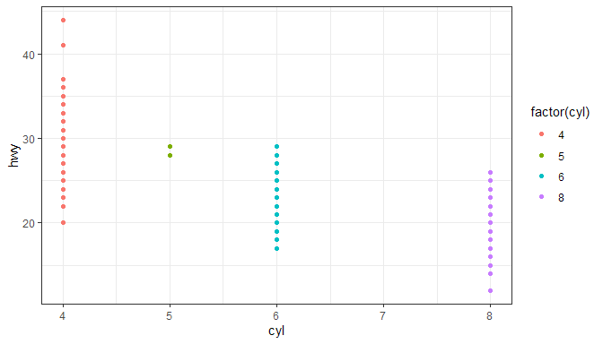

```r
ggplot(mpg, aes(cyl, hwy, colour = factor(cyl))) +
  geom_point() +
  geom_debug()
```

Below we show how `geom_debug()` can be used together with functions that take a data frame as input and return a value that can be printed. We use here `head()` but other functions such `summary()`, `nrow()` and `colnames()` as well as user defined functions can be useful when `data` is large. As shown here, additional arguments can be passed by name to the function.

```r
ggplot(my.data, aes(x, y, colour = group)) +
  geom_point() +
  geom_debug(summary.fun = head, summary.fun.args = list(n = 3))
```

```
##    colour x         y PANEL group
## 1 #F8766D 1 -27205.45     1     1
## 2 #00BFC4 2 -14242.65     1     2
## 3 #F8766D 3  45790.92     1     1
```

When using a statistic that modifies the data, we can pass `geom_debug()` as argument in the call to this statistic. In this way the data printed to the console will be those returned by the statistics and received by the geometry.

```
## # A tibble: 4 x 7
##   colour      x group     y  ymin  ymax PANEL
##   <chr>   <dbl> <int> <dbl> <dbl> <dbl> <fct>
## 1 #F8766D     4     1  28.8  28.3  29.3 1
## 2 #7CAE00     5     2  28.8  28.5  29   1
## 3 #00BFC4     6     3  22.8  22.4  23.2 1
## 4 #C77CFF     8     4  17.6  17.2  18.0 1
```

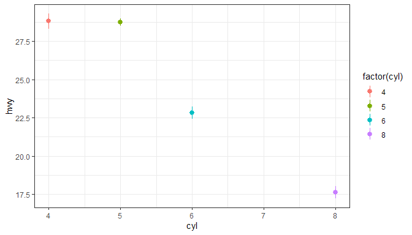

```r
ggplot(mpg, aes(cyl, hwy, colour = factor(cyl))) +
  stat_summary(fun.data = "mean_se") +
  stat_summary(fun.data = "mean_se", geom = "debug")
```

As shown above an important use of `geom_debug()` it to display the data returned by a statistic and received as input by geometries. Not all extensions to ‘ggplot2’ document all the computed variables returned by statistics. In other cases like in the next example, the values returned will depend on the arguments passed. While in the previous example the statistic returned a data frame with one row per group, here the returned data frame has 160 rows. The data are by default plotted as a line with a confidence band.

```
## # A tibble: 160 x 8
##    colour      x      y    ymin   ymax     se PANEL group
##    <chr>   <dbl>  <dbl>   <dbl>  <dbl>  <dbl> <fct> <int>
##  1 #F8766D  1    23456. -26311. 73223. 24738. 1         1
##  2 #F8766D  2.24 18462. -28860. 65784. 23523. 1         1
##  3 #F8766D  3.48 13883. -31095. 58861. 22358. 1         1
##  4 #F8766D  4.72  9719. -33018. 52456. 21244. 1         1
##  5 #F8766D  5.96  5970. -34632. 46573. 20183. 1         1
##  6 #F8766D  7.20  2637. -35941. 41215. 19176. 1         1
##  7 #F8766D  8.44  -281. -36948. 36386. 18227. 1         1
##  8 #F8766D  9.68 -2783. -37657. 32090. 17335. 1         1
##  9 #F8766D 10.9  -4871. -38072. 28331. 16504. 1         1
## 10 #F8766D 12.2  -6543. -38197. 25112. 15735. 1         1
## # ... with 150 more rows
```

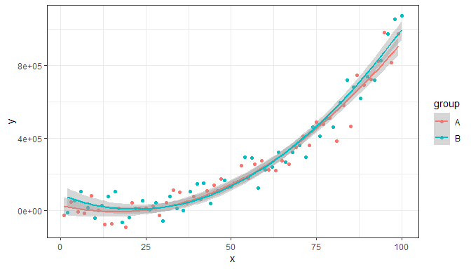

```r
ggplot(my.data, aes(x, y, colour = group)) +
  geom_point() +
  stat_smooth(method = "lm", formula = y ~ poly(x, 2)) +
  stat_smooth(method = "lm", formula = y ~ poly(x, 2), geom = "debug")
```